# PSTAT 174/274, Spring 2023: Homework #4

### Question 4

For the processes X<sub>t</sub> = 0.4X<sub>t−1</sub> + Z<sub>t</sub> − 0.7Z<sub>t−1</sub>,  
(i) Simulate and plot 100 values of the processes

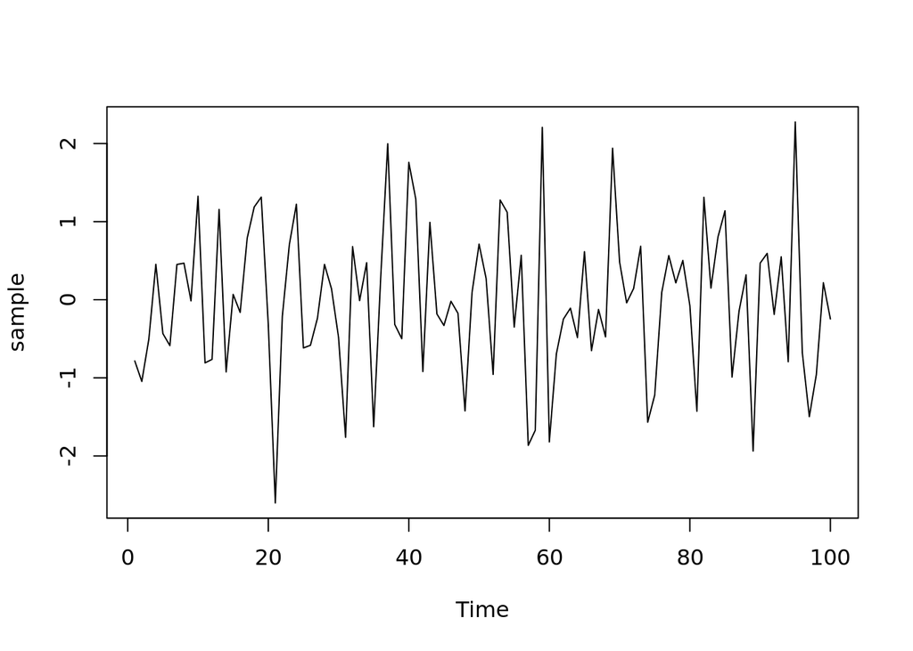

```r
options(scipen = 9)
set.seed(333)
sample <- arima.sim(n=100, list(ar=c(0.4), ma=c(-0.7), sd=1))
plot(sample)
```

(ii) Compute and graph their theoretical ACF and PACF using R.

```r
acf_model = ARMAacf(ar = 0.4, ma=c(-0.7), lag.max=10, pacf=FALSE)

pacf_model = ARMAacf(ar = 0.4, ma=c(-0.7), lag.max=10, pacf=TRUE)

par(mfrow=c(1,2))

plotArmaTrueacf(list(ar = 0.4, ma=c(-0.7)), lag.max=10, pacf=FALSE, plot=TRUE,
          xlab="Lag", ylab=c("ACF"),
          ylim=c(-0.25, 0.6), xlim=c(0,10), type="h")
```

```
## $roots
## [1] 0.4
##
## $acf
##              0              1              2              3              4
##  1.00000000000 -0.23225806452 -0.09290322581 -0.03716129032 -0.01486451613
##              5              6              7              8              9
## -0.00594580645 -0.00237832258 -0.00095132903 -0.00038053161 -0.00015221265
##             10
## -0.00006088506
##
## $periodicity
## [1] damping period
## <0 rows> (or 0-length row.names)
```

```r
plotArmaTrueacf(list(ar = 0.4, ma=c(-0.7)), lag.max=10, pacf=TRUE, plot=TRUE,
          xlab="Lag", ylab=c("Partial ACF"),
          ylim=c(-0.25, 0.6), xlim=c(1,10), type="h")
```

```
## $roots
## [1] 0.4
##
## $pacf
##  [1] -0.23225806 -0.15522020 -0.10629612 -0.07362436 -0.05127270 -0.03580090
##  [7] -0.02502988 -0.01751039 -0.01225367 -0.00857633
##
## $periodicity
## [1] damping period
## <0 rows> (or 0-length row.names)
```

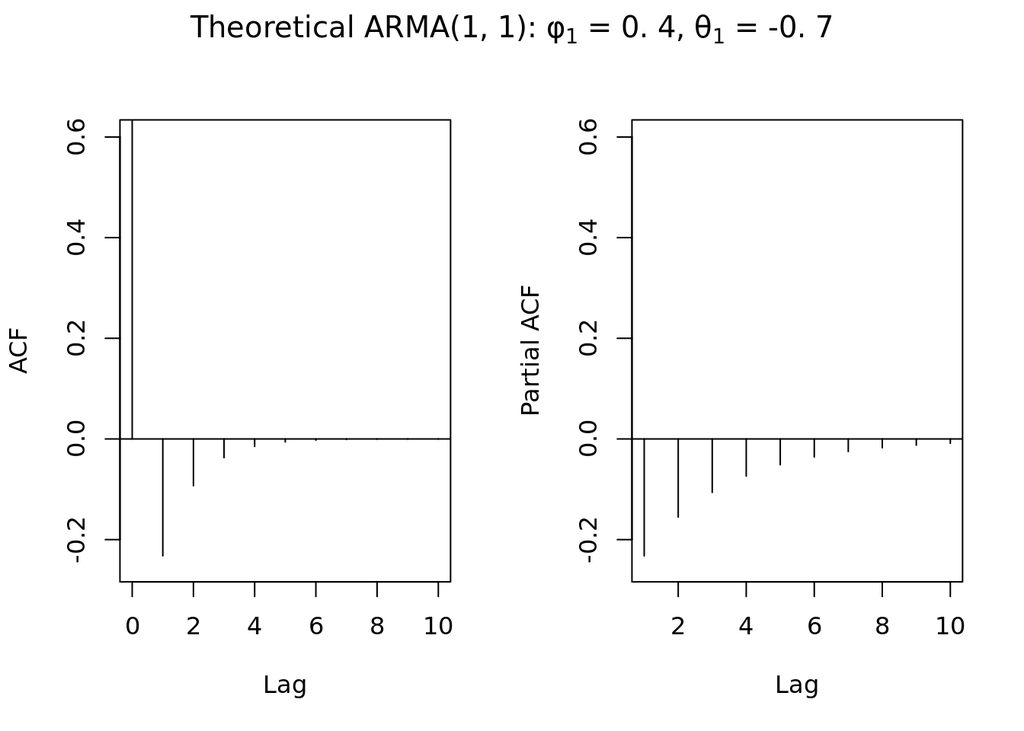

```r
title(main=TeX(r'(Theoretical ARMA(1,1): $\phi_1$ = 0.4, $\theta_1$ = -0.7)'), line=-1, outer=TRUE, cex=0.5)
```

(iii) Compute and graph their sample ACF and PACF using R. How do sample functions compare to their theoretical counterparts?

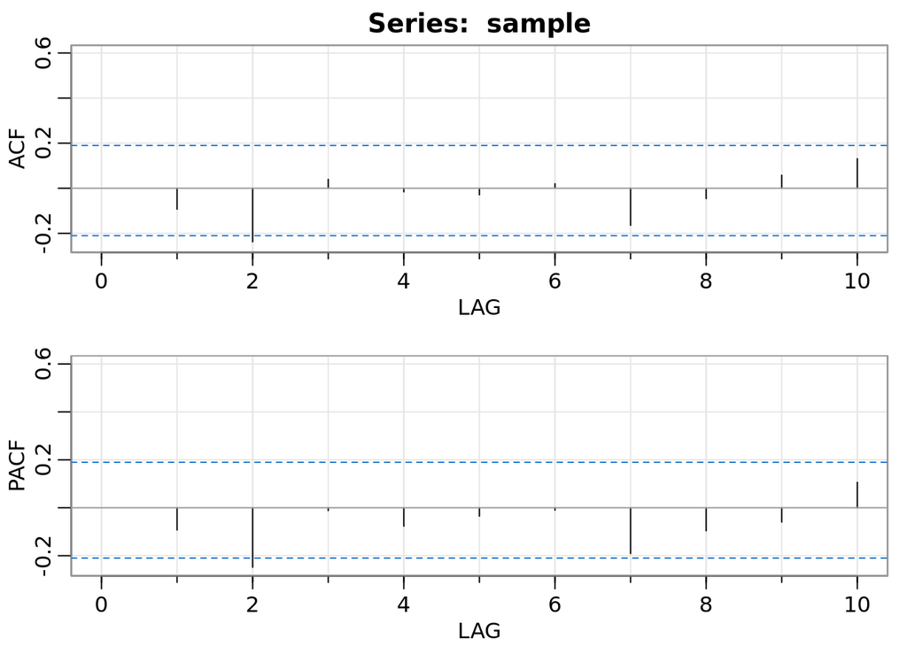

```
##       [,1]  [,2]  [,3]  [,4]  [,5]  [,6]  [,7]  [,8]  [,9] [,10]
## ACF  -0.09 -0.24  0.04 -0.02 -0.03  0.02 -0.16 -0.05  0.06  0.13
## PACF -0.09 -0.25 -0.01 -0.08 -0.03 -0.01 -0.19 -0.10 -0.06  0.11
```

```r
acf2(sample, max.lag = 10, xlim=c(0,10), ylim=c(-0.25,0.6))
```

```r
acf2(sample, max.lag = 10, xlim=c(0,10), ylim=c(-0.25,0.6), plot=FALSE)
```

```
##               ACF         PACF
##  [1,] -0.09267651 -0.092676507
##  [2,] -0.23735405 -0.248073675
##  [3,]  0.03963810 -0.011614970
##  [4,] -0.01574868 -0.076672333
##  [5,] -0.02907488 -0.034960281
##  [6,]  0.01997462 -0.009801421
##  [7,] -0.16427130 -0.190926235
##  [8,] -0.04582826 -0.096151621
##  [9,]  0.05798451 -0.059514875
## [10,]  0.13106158  0.106156842
```

There are not enough sample observations for the sample pacf and acf to be a good estimation of the theoretical pacf and acf.  
(iv) Analyze smoothness of the simulated processes using their ACF’s. Please include the code with clear comments explaining the meaning of the code. Make sure to label the graphs.

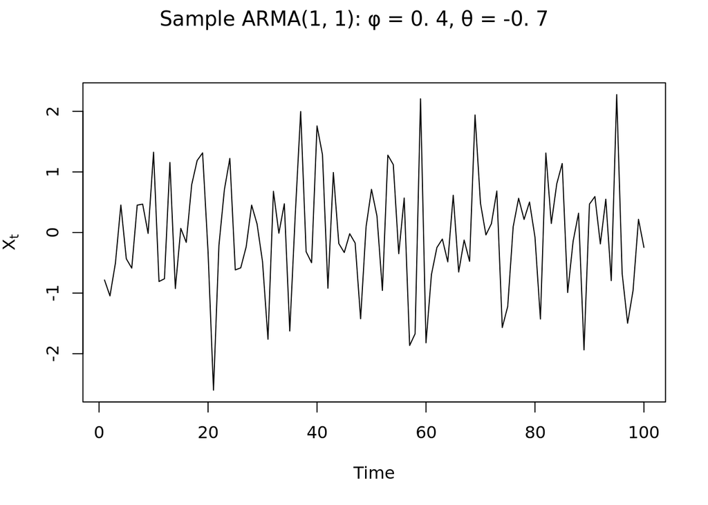

```r
# Unaltered ACF
plot(sample, ylab = TeX(r'($X_t$)'), xlab="Time")
title(main=TeX(r'(Sample ARMA(1,1): $\phi$ = 0.4, $\theta$ = -0.7)'), line=-1, outer=TRUE, cex=0.5)
```

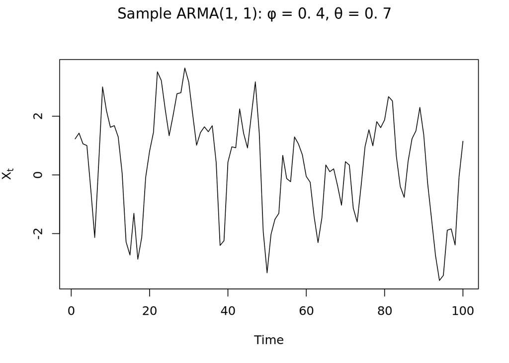

```r
# Smoothing by changing ma = -0.7 to ma = 0.7
sample2 <- arima.sim(n=100, list(ar=c(0.4), ma=c(0.7), sd=1))
plot(sample2, ylab = TeX(r'($X_t$)'), xlab="Time")
title(main=TeX(r'(Sample ARMA(1,1): $\phi$ = 0.4, $\theta$ = 0.7)'), line=-1, outer=TRUE, cex=0.5)
```

**The following problems are for students enrolled in PSTAT 274 ONLY**

### Question GE1

Let {Y<sub>t</sub>} be the AR(1) plus noise time series defined by Y<sub>t</sub> = X<sub>t</sub> +W<sub>t</sub>, where {W<sub>t</sub>} ∼ WN(0, σ<sub>W</sub><sup>2</sup>), {X<sub>t</sub>} is the AR(1) process X<sub>t</sub> − $\phi$ X<sub>t−1</sub> = Z<sub>t</sub>,  
{Z<sub>t</sub>} ∼ WN(0, σ<sub>Z</sub><sup>2</sup>), |$\phi$|<1, and E(W<sub>s</sub>Z<sub>t</sub>) = 0 for all t, s.

1. Show that {Y<sub>t</sub>} is stationary and find its autocovariance function.
   $$\begin{aligned}
   \text{Given:} &\\
   &\begin{cases}
   X_t=\phi_1X_{t-1}+Z_t\\
   |\phi_1|<1\\
   Z_t=WN(0,\ \sigma_Z^2)\\
   Y_t=X_t+W_t\\
   W_t=WN(0,\ \sigma_W^2)\\
   E[W_sZ_t]=0\\
   \end{cases}\\\\
   X_t\ &\text{is a stationary AR(1) process}\\
   &\text{because } \phi(z) = 1-\phi_1z = 0\\
   &\ \ \ \ \ \ \ \ \ \ \ \ \ \ \ \ \ \ \ \ 1=\phi_1z\\
   &\ \ \ \ \ \ \ \ \ \ \ \ \ \ \ \ \ \ \ \ 1/\phi_1 = z\\
   &\ \ \ \ \ \ \ \ \ \ \ \ \ \ \ \ \ \ \ \ \text{if } \phi_1<1,\
   \text{then } 1/\phi_1 >1,\\
   &\ \ \ \ \ \ \ \ \ \ \ \ \ \ \ \ \ \ \ \ \text{thus }z>1\\
   \end{aligned}$$
   $$\begin{aligned}
   Var[X_t] &= \gamma_X(0)= \frac{\sigma_Z^2}{1-\phi_1^2}\\\\
   E[Y_t]&=E[X_t+W_t]\\
   &= E[X_t]+E[W_t] = 0 \\\\
   Var[Y_t] &= Var[X_t+W_t]\\
   &= E[(\phi_1X_{t-1}+Z_t+W_t)X_{t-k}]\\
   &=E[\phi_1X_{t-1}X_{t-k}]\ +\ E[Z_tX_{t-k}]\ +\ E[W_tX_{t-k}]\\\\
   &for\ \ k=0: \ \ \ \
   \begin{cases}
   E[\phi_1X_{t-1}X_{t}] \ \ \ \ \ \ \ \ \ \ = \phi_1\gamma_X(1) \\
   E[Z_tX_{t}] = E[Z_t^2] \ \ \ = \sigma_Z^2\\
   E[W_tX_{t}] = E[W_t^2] \ = \sigma_W^2
   \end{cases}\\\\
   & Var[Y_t]=\gamma_Y(0)
   =\phi_1^2\gamma_X(0)+\sigma_Z^2+\sigma_W^2\\\\
   \end{aligned}$$

$$\begin{aligned}
\text{If}\ \ &\phi_1^2\gamma_X(0) +\sigma_Z^2
=\frac{\phi_1^2\sigma_Z^2}{1-\phi_1^2} +
\frac{\sigma_Z^2(1-\phi_1^2)}{1-\phi_1^2}=
\frac{\sigma_Z^2}{1-\phi_1^2}, \\\\
\text{then}\ \ &\phi_1^2\gamma_X(0) +\sigma_Z^2+\sigma_W^2
=\frac{\phi_1^2(\sigma_Z^2+\sigma_W^2)}{1-\phi_1^2} +
\frac{(\sigma_Z^2+\sigma_W^2)(1-\phi_1^2)}{1-\phi_1^2}=
\frac{\sigma_Z^2+\sigma_W^2}{1-\phi_1^2} \\\\
&\gamma_Y(k)=\begin{cases}\frac{\sigma_Z^2+\sigma_W^2}{1-\phi_1^2} \
\ \ \ \ \ \ \ \ \ \ \ \text{for
k=0}\\\\ \frac{\phi_1^k(\sigma_Z^2+\sigma_W^2)}{1-\phi_1^2}\ \ \ \ \ \
\ \text{for k}\geq1
\end{cases}\
\end{aligned}$$
(b) Show that the time series U<sub>t</sub> := Y<sub>t</sub> − $\phi Y_{t−1}$ is 1-correlated (i.e., γ<sub>U</sub>(h) = 0 for h > 1) and hence is MA(1) process.
$$\begin{aligned}
U_t&=Y_t - \phi Y_{t-1}\\
&= X_t+W_t-\phi (X_{t-1}+W_{t-1})\\
&= X_t-\phi X_{t-1}+W_t-\phi W_{t-1}\\
&=(1-\phi B)(X_t+W_t)\\
\text{This is a MA(1) process with }& Z_t \text{ substituted for }
X_t+W_t\\
& \&\ X_t \text{ substituted for }Y_t
\end{aligned}$$
(c) Conclude from (b) that {Y<sub>t</sub>} is an ARMA(1,1) process and express the three parameters of this model in terms of $\phi$, σ<sub>W</sub><sup>2</sup> and σ<sub>Z</sub><sup>2</sup>.
$$U_t =(1-\phi B)(X_t+W_t)\\
Y_t - \phi Y_{t-1} = (1-\phi B)(X_t+W_t)\\
(1-\phi B)(Y_t) = (1-\phi B)(X_t+W_t)\\
\text{Thus, it is an ARMA(1,1) Process}$$

### Question GE2

Find the ACVF, ACF and PACF for {X<sub>t</sub>} when X<sub>t</sub> = ΦX<sub>t−4</sub> + Z<sub>t</sub>, |Φ| < 1.

$$X_t-\Phi X_{t-4}=Z_t\\
= (1-\Phi B^{1*4})X_{t} = Z_t\\
SARIMA(0,0,0) × (1,0,0)_4\\
= AR(1)_4\\
\gamma_X(h)=
\begin{cases}
\frac{\sigma^2}{1-\Phi^2}\ \ \ for\ h = 0\\
\frac{\Phi^k\sigma^2}{1-\Phi^2}\ \ \ for\ h=4k,\ k =1,2,3...
\end{cases}\\$$

$$\begin{aligned}
\rho_X(h)=
\begin{cases}
1 \ \ \ \ \ \ \ \ \ \ for\ k = 0\\
\Phi^k\ \ \ for\ h=4k,\ k =1,2,3...\\
\end{cases}\\\\\\
PACF = \begin{cases}
\Phi\ \ \ for\ h=4,\\
0 \ \ \ \ otherwise
\end{cases}\\\\\\
\end{aligned}$$

```r
phi=c(rep(0,3), 0.8)
plotArmaTrueacf(list(ar = phi), lag.max=12, pacf=FALSE, plot=FALSE)
```

```
## $roots
## [1] -0.9457416+0.0000000i  0.0000000+0.9457416i  0.0000000-0.9457416i
## [4]  0.9457416+0.0000000i
##
## $acf
##     0     1     2     3     4     5     6     7     8     9    10    11    12
## 1.000 0.000 0.000 0.000 0.800 0.000 0.000 0.000 0.640 0.000 0.000 0.000 0.512
##
## $periodicity
##     damping period
## 1 0.9457416      4
```

```r
plotArmaTrueacf(list(ar = phi), lag.max=10, pacf=TRUE, plot=FALSE)
```

```
## $roots
## [1] -0.9457416+0.0000000i  0.0000000+0.9457416i  0.0000000-0.9457416i
## [4]  0.9457416+0.0000000i
##
## $pacf
##  [1]  0.000000e+00  0.000000e+00  0.000000e+00  8.000000e-01  0.000000e+00
##  [6]  0.000000e+00  0.000000e+00 -3.083953e-16  0.000000e+00  0.000000e+00
##
## $periodicity
##     damping period
## 1 0.9457416      4
```